# Course Notes | Text Mining with R | DataCamp

## Exercise

So there are more non-complaints than complaints in `twitter_data`. You might be starting to question whether or not this data is actually from Twitter! There are a few other columns of interest in `twitter_data` that would be helpful to explore before you get to the tweets themselves. Every tweet includes the number of followers that user has in the `usr_followers_count` column. Do you expect those who complain to have more users or fewer users, on average, than those who don’t complain? You can use grouped summaries to quickly and easily provide an answer.

## Instructions

- Group the data by `complaint_label`.
- Compute the average, minimum, and maximum, number of `usr_followers_count`.

## script.R

```r
# Start with the data frame
twitter_data %>%
  # Group the data by whether or not the tweet is a complaint
  group_by(complaint_label) %>%
  # Compute the mean, min, and max follower counts
  summarize(
    avg_followers = mean(usr_followers_count),
    min_followers = min(usr_followers_count),
    max_followers = max(usr_followers_count)
  )
```

```
## # A tibble: 2 x 4
##   complaint_label avg_followers min_followers max_followers
##   <chr>                   <dbl>         <dbl>         <dbl>
## 1 Complaint               3234.             0       1259803
## 2 Non-Complaint           4487.             0       2200851
```

## Counting categorical data

**Column types**

```r
review_data %>% head(2)
```

```
## # A tibble: 2 x 5
##   Date    Product              Stars Title    Review
##   <chr>   <chr>                <dbl> <chr>    <chr>
## 1 2/28/15 iRobot Roomba 650 f…     5 Five St… You would not believe how we…
## 2 1/12/15 iRobot Roomba 650 f…     4 Four St… You just walk away and it do…
```

**Summarizing with n()**

```r
review_data %>%
  summarise(number_rows = n())
```

```
## # A tibble: 1 x 1
##   number_rows
##         <int>
## 1        1833
```

```r
# group by
review_data %>%
  group_by(Product) %>%
  summarise(number_rows = n())
```

```
## # A tibble: 2 x 2
##   Product                                  number_rows
##   <chr>                                          <int>
## 1 iRobot Roomba 650 for Pets                       633
## 2 iRobot Roomba 880 for Pets and Allergies        1200
```

**Summarizing with count()**

```r
review_data %>%
  count(Product)
```

```
## # A tibble: 2 x 2
##   Product                                      n
##   <chr>                                    <int>
## 1 iRobot Roomba 650 for Pets                 633
## 2 iRobot Roomba 880 for Pets and Allergies  1200
```

```r
review_data %>%
  count(Product) %>%
  arrange(desc(n))
```

```
## # A tibble: 2 x 2
##   Product                                      n
##   <chr>                                    <int>
## 1 iRobot Roomba 880 for Pets and Allergies  1200
## 2 iRobot Roomba 650 for Pets                 633
```

```r
review_data %>%
  count(Product, sort = TRUE)
```

```
## # A tibble: 2 x 2
##   Product                                      n
##   <chr>                                    <int>
## 1 iRobot Roomba 880 for Pets and Allergies  1200
## 2 iRobot Roomba 650 for Pets                 633
```

## Counting user types

### Exercise

Counts are the essential summary for categorical data. Since text is categorical, it’s important to get comfortable computing counts. The `twitter_data` is composed of complaints and non-complaints, as indicated by the `complaint_label` column, and also includes a column indicating whether or not the user is verified (i.e., they have been confirmed by Twitter to be who they say they are) called `usr_verified`. Note that column is of type `<lgl>`, meaning logical. Do verified users complain more?

### Instructions

- Load the `tidyverse` package, which includes `dplyr` and `ggplot2`.
- Filter the data to only keep tweets that are complaints.
- Count the number of verified and non-verified users that have complained.

### script.R

```r
# Load the tidyverse package
library(tidyverse)

twitter_data %>%
  # Filter for just the complaints
  filter(complaint_label == "Complaint") %>%
  # Count the number of verified and non-verified users
  count(usr_verified) %>%
  head(3)
```

```
## # A tibble: 2 x 2
##   usr_verified     n
##   <lgl>        <int>
## 1 FALSE         1650
## 2 TRUE            26
```

## Summarizing user types

### Exercise

Since you can use the `count()` wrapper, why bother counting rows in a group as part of a grouped summary? Sometimes you want a more detailed summary, and knowing how to compute a count as part of a grouped summary that mixes numeric and categorical summaries can come in handy.

### Instructions

- Group `twitter_data` by whether or not a user is verified.
- Compute the average number of followers for each type of user. Call this new column `avg_followers`.
- Count the number of verified and non-verified users. For consistency, call this new column `n`.

### script.R

```r
library(tidyverse)

twitter_data %>%
  # Group by whether or not a user is verified
  group_by(usr_verified) %>%
  summarize(
    # Compute the average number of followers
    avg_followers = mean(usr_followers_count),
    # Count the number of users in each category
    n = n()
  ) %>%
  head(3)
```

```
## # A tibble: 2 x 3
##   usr_verified avg_followers     n
##   <lgl>                <dbl> <int>
## 1 FALSE                1999.  6927
## 2 TRUE               133849.   117
```

## Tokenizing and cleaning

**Using tidytext**

[figure not shown]

https://github.com/juliasilge/tidytext

**Tokenizing text**

Some natural language processing (NLP) vocabulary:

- Bag of words: Words in a document are independent Every separate body of text is a document
- Every unique word is a term
- Every occurrence of a term is a token
- Creating a bag of words is called tokenizing

**Using unnest_tokens()**

```r
library(tidytext)

tidy_review <- review_data %>%
  unnest_tokens(word, Review)

tidy_review %>%
  head(3)
```

```
## # A tibble: 3 x 5
##   Date    Product                    Stars Title      word
##   <chr>   <chr>                      <dbl> <chr>      <chr>
## 1 2/28/15 iRobot Roomba 650 for Pets     5 Five Stars you
## 2 2/28/15 iRobot Roomba 650 for Pets     5 Five Stars would
## 3 2/28/15 iRobot Roomba 650 for Pets     5 Five Stars not
```

**Counting words**

```r
tidy_review %>%
  count(word) %>%
  arrange(desc(n)) %>%
  head(3)
```

```
## # A tibble: 3 x 2
##   word      n
##   <chr> <int>
## 1 the   11785
## 2 it     7905
## 3 and    6794
```

**Using anti_join()**

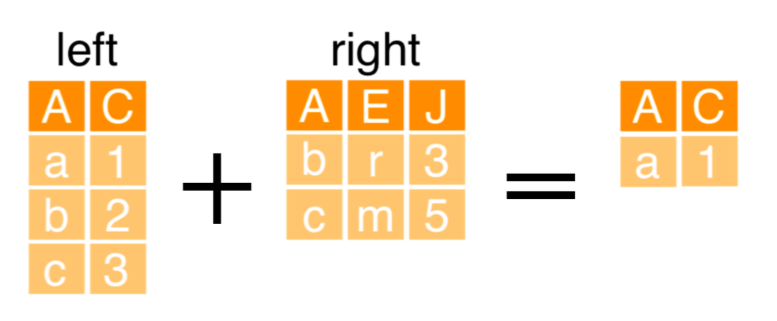

```r
tidy_review2 <- review_data %>%
  unnest_tokens(word, Review) %>%
  anti_join(stop_words)
## Joining, by = "word"

tidy_review2 %>%
  head(3)
```

```
## # A tibble: 3 x 5
##   Date     Product                    Stars Title            word
##   <chr>    <chr>                      <dbl> <chr>            <chr>
## 1 1/12/15  iRobot Roomba 650 for Pets     4 Four Stars       walk
## 2 1/12/15  iRobot Roomba 650 for Pets     4 Four Stars       rest
## 3 12/26/13 iRobot Roomba 650 for Pets     5 Awesome love it. roomba
```

## Tokenizing and counting

### Exercise

Explore the content of the airline tweets in `twitter_data` through word counts. The content of each tweet is in the `tweet_text` column.

### Instructions

- Load the tidyverse and tidytext packages.
- Tokenize the tweets in the `tweet_text` column.
- Compute word counts using the tokenized text.
- Arrange the counts in descending order.

### script.R

```r
# Load the tidyverse and tidytext packages
library(tidyverse)
library(tidytext)

tidy_twitter <- twitter_data %>%
  # Tokenize the twitter data
  unnest_tokens(word, tweet_text)

tidy_twitter %>%
  # Compute word counts
  count(word) %>%
  # Arrange the counts in descending order
  arrange(desc(n))
```

```
## # A tibble: 18,526 x 2
##    word      n
##    <chr> <int>
##  1 to     2834
##  2 the    2212
##  3 a      1989
##  4 i      1752
##  5 t.co   1405
##  6 http   1361
##  7 for    1356
##  8 you    1345
##  9 on     1289
## 10 and    1153
## # … with 18,516 more rows
```

## Cleaning and counting

### Exercise

Remove stop words to explore the content of just the airline tweets classified as complaints in `twitter_data`.

### Instructions

- Tokenize the tweets in `twitter_data`. Name the column with tokenized words as `word`.
- Remove the default stop words from the tokenized `twitter_data`.
- Filter to keep the complaints only.
- Compute word counts using the tokenized, cleaned text and arrange in descending order by count.

### sript.R

```r
tidy_twitter <- twitter_data %>%
  # Tokenize the twitter data
  unnest_tokens(word, tweet_text) %>%
  # Remove stop words
  anti_join(stop_words)
## Joining, by = "word"

tidy_twitter %>%
  # Filter to keep complaints only
  filter(complaint_label == "Complaint") %>%
  # Compute word counts and arrange in descending order
  count(word) %>%
  arrange(desc(n))
```

```
## # A tibble: 3,848 x 2
##    word                n
##    <chr>           <int>
##  1 flight            459
##  2 united            362
##  3 americanair       294
##  4 usairways         207
##  5 time              167
##  6 delta             141
##  7 service           137
##  8 2                 129
##  9 delayed           123
## 10 british_airways   121
## # … with 3,838 more rows
```